```r
library(moments)
library(corrplot)
library(rmarkdown); library(knitr); library(moments);
library(scatterplot3d); library(corrplot); library(pso)
library(psych); library(GPArotation); library(lavaan)
```

## Airline Flight Delays

Hunter Dunn and Breanna Ranglall

```r
#Read in Files
Flights <- read.csv("C:/Users/brezy/OneDrive - University of St. Thomas/Certificates/flights with Top 50.csv")
Flights <- Flights[,c("DAY_OF_WEEK", "Top50", "SCHEDULED_TIME", "ELAPSED_TIME", "DISTANCE", "AIR_SYSTEM_DELAY", "SECURITY_DELAY", "LATE_AIRCRAFT_DELAY", "WEATHER_DELAY", "ARRIVAL_DELAY")]

#Pulling Data from just January
Flights <- Flights[1:469969,]

#Remove missing data
Flights <- Flights |>
  na.omit(Flights)

#Creat correlation plot
R <- cor(Flights[,c("DAY_OF_WEEK", "Top50", "SCHEDULED_TIME", "ELAPSED_TIME", "DISTANCE", "AIR_SYSTEM_DELAY", "SECURITY_DELAY", "LATE_AIRCRAFT_DELAY", "WEATHER_DELAY")])
R
```

```
##                      DAY_OF_WEEK        Top50 SCHEDULED_TIME ELAPSED_TIME
## DAY_OF_WEEK          1.000000000  0.004647423     0.02643191   0.02743858
## Top50                0.004647423  1.000000000     0.29302549   0.27077713
## SCHEDULED_TIME       0.026431912  0.293025490     1.00000000   0.96751784
## ELAPSED_TIME         0.027438579  0.270777133     0.96751784   1.00000000
## DISTANCE             0.035263236  0.274584544     0.97753728   0.94265689
## AIR_SYSTEM_DELAY     0.007015974 -0.005924834     0.04676574   0.18717078
## SECURITY_DELAY       0.004648905 -0.009965579     0.01213185   0.01007314
## LATE_AIRCRAFT_DELAY  0.009025461 -0.051336053    -0.06580599  -0.10655259
## WEATHER_DELAY       -0.023941081  0.047222155     0.01130569   0.02648370
##                        DISTANCE AIR_SYSTEM_DELAY SECURITY_DELAY
## DAY_OF_WEEK          0.03526324      0.007015974    0.004648905
## Top50                0.27458454     -0.005924834   -0.009965579
## SCHEDULED_TIME       0.97753728      0.046765743    0.012131849
## ELAPSED_TIME         0.94265689      0.187170779    0.010073140
## DISTANCE             1.00000000      0.033560389    0.013394334
## AIR_SYSTEM_DELAY     0.03356039      1.000000000   -0.011069771
## SECURITY_DELAY       0.01339433     -0.011069771    1.000000000
## LATE_AIRCRAFT_DELAY -0.06341014     -0.136530520   -0.009294920
## WEATHER_DELAY       -0.00225577      0.022809360   -0.003666716
##                     LATE_AIRCRAFT_DELAY WEATHER_DELAY
## DAY_OF_WEEK                 0.009025461  -0.023941081
## Top50                      -0.051336053   0.047222155
## SCHEDULED_TIME             -0.065805994   0.011305691
## ELAPSED_TIME               -0.106552587   0.026483704
## DISTANCE                   -0.063410143  -0.002255770
## AIR_SYSTEM_DELAY           -0.136530520   0.022809360
## SECURITY_DELAY             -0.009294920  -0.003666716
## LATE_AIRCRAFT_DELAY         1.000000000  -0.033017172
## WEATHER_DELAY              -0.033017172   1.000000000
```

#Find Intrinsic Dimensionality

Eigen Values:

```r
eigen(R)$values
```

```
## [1] 3.06434426 1.13753266 1.03046051 1.00064156 0.97804329 0.90333954 0.82709865
## [8] 0.04422417 0.01431536
```

Intrinsic Dimensonality using Kaiser:

```r
sum((eigen(R)$values)>1)
```

```
## [1] 4
```

Intrinsic Dimensonality using Jollife’s:

```r
sum((eigen(R)$values)>0.70)
```

```
## [1] 7
```

We chose to use Jollife’s criterion because of the dramatic drop off of the values after the 0.70 cut off.

#Optimal Orthogonally Rotated Matrix

Use pca() to extract the optimally orthogonally rotated loading matrix for the set of predictor dimensions:

```r
A2 <- pca(r = R, nfactors = 7, rotate = "varimax")$loadings[]
A2
```

```
##                              RC1          RC2          RC6          RC3
## DAY_OF_WEEK          0.019636768  0.003195134  0.004995623 -0.012004784
## Top50                0.189579838 -0.009481298 -0.021871095  0.023789512
## SCHEDULED_TIME       0.989256301 -0.010481109 -0.016007732  0.003346486
## ELAPSED_TIME         0.973427205  0.133181564 -0.048885855  0.017555985
## DISTANCE             0.983092932 -0.025991855 -0.015241337 -0.010065295
## AIR_SYSTEM_DELAY     0.057161675  0.995681492 -0.067215237  0.010871558
## SECURITY_DELAY       0.008294814 -0.005911956 -0.004706307 -0.001782293
## LATE_AIRCRAFT_DELAY -0.048687047 -0.067058512  0.996182237 -0.015851003
## WEATHER_DELAY        0.005566926  0.010765363 -0.015702538  0.999467550
##                              RC4           RC5           RC7
## DAY_OF_WEEK          0.002256486  0.9997139277  0.0006853718
## Top50               -0.006048728  0.0006921096  0.9812672051
## SCHEDULED_TIME       0.004389734  0.0070266792  0.1071479377
## ELAPSED_TIME         0.003038399  0.0081399625  0.0875956939
## DISTANCE             0.005504609  0.0161250708  0.0894691195
## AIR_SYSTEM_DELAY    -0.006010122  0.0032234990 -0.0092535812
## SECURITY_DELAY       0.999916559  0.0022550295 -0.0057150448
## LATE_AIRCRAFT_DELAY -0.004759983  0.0050521525 -0.0210045932
## WEATHER_DELAY       -0.001785053 -0.0120184256  0.0225684872
```

Create a correlation plot of the rotated loading matrix:

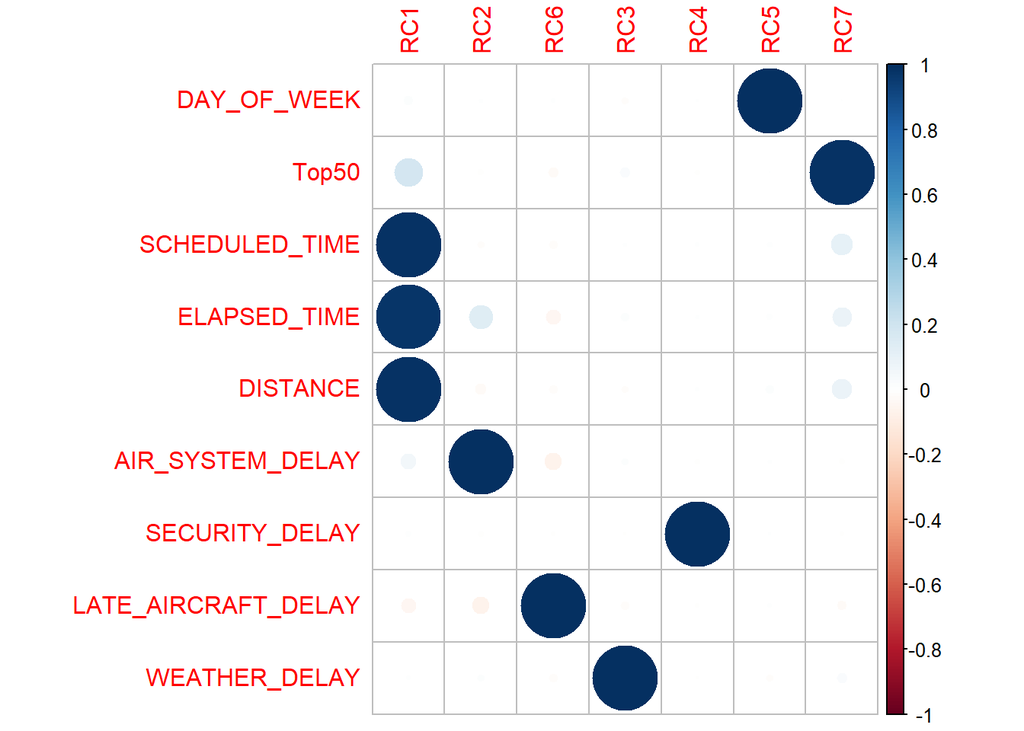

```r
corrplot(A2)
```

#Optimal Oblique Rotated Matrix

Use pca() to extract the optimally obliquely rotated loading matrix and the factor correlation matrix:

```r
pca(r = R, nfactors = 7, rotate = "oblimin")
```

```
## Principal Components Analysis
## Call: principal(r = r, nfactors = nfactors, residuals = residuals,
##     rotate = rotate, n.obs = n.obs, covar = covar, scores = scores,
##     missing = missing, impute = impute, oblique.scores = oblique.scores,
##     method = method, use = use, cor = cor, correct = 0.5, weight = NULL)
## Standardized loadings (pattern matrix) based upon correlation matrix
##                      TC1   TC2   TC6   TC3  TC7  TC5 TC4   h2      u2 com
## DAY_OF_WEEK         0.00  0.00  0.00  0.00 0.00 1.00   0 1.00 1.6e-06   1
## Top50               0.00  0.00  0.00  0.00 1.00 0.00   0 1.00 2.9e-06   1
## SCHEDULED_TIME      0.99 -0.04  0.01  0.00 0.01 0.00   0 0.99 9.4e-03   1
## ELAPSED_TIME        0.97  0.10 -0.02  0.01 0.00 0.00   0 0.98 2.4e-02   1
## DISTANCE            0.99 -0.06  0.01 -0.01 0.00 0.01   0 0.98 2.4e-02   1
## AIR_SYSTEM_DELAY    0.00  1.00  0.00  0.00 0.00 0.00   0 1.00 5.8e-04   1
## SECURITY_DELAY      0.00  0.00  0.00  0.00 0.00 0.00   1 1.00 4.7e-08   1
## LATE_AIRCRAFT_DELAY 0.00  0.00  1.00  0.00 0.00 0.00   0 1.00 1.3e-05   1
## WEATHER_DELAY       0.00  0.00  0.00  1.00 0.00 0.00   0 1.00 1.4e-05   1
##
##                        TC1  TC2  TC6  TC3  TC7  TC5  TC4
## SS loadings           2.92 1.02 1.00 1.00 1.00 1.00 1.00
## Proportion Var        0.32 0.11 0.11 0.11 0.11 0.11 0.11
## Cumulative Var        0.32 0.44 0.55 0.66 0.77 0.88 0.99
## Proportion Explained  0.33 0.11 0.11 0.11 0.11 0.11 0.11
## Cumulative Proportion 0.33 0.44 0.55 0.66 0.78 0.89 1.00
##
##  With component correlations of
##       TC1   TC2   TC6   TC3   TC7   TC5   TC4
## TC1  1.00  0.09 -0.08  0.01  0.28  0.03  0.01
## TC2  0.09  1.00 -0.14  0.03 -0.01  0.01 -0.01
## TC6 -0.08 -0.14  1.00 -0.03 -0.05  0.01 -0.01
## TC3  0.01  0.03 -0.03  1.00  0.05 -0.02  0.00
## TC7  0.28 -0.01 -0.05  0.05  1.00  0.00 -0.01
## TC5  0.03  0.01  0.01 -0.02  0.00  1.00  0.00
## TC4  0.01 -0.01 -0.01  0.00 -0.01  0.00  1.00
##
## Mean item complexity =  1
## Test of the hypothesis that 7 components are sufficient.
##
## The root mean square of the residuals (RMSR) is  0
##
## Fit based upon off diagonal values = 1
```

Based on the factor correlation matrix, no absolute values exceed the common threshold of 0.30. ‘TC1’ and ‘TC7’ are close at 0.28, but it still doesn’t exceed the threshold. Therefore, oblique rotation is not necessary, we will use orthogonal rotation.

#Variance

Use pca() to summarize the variance explained by the orthogonal rotation:

```r
pca(r = R, nfactors = 7, rotate = "varimax")
```

```
## Principal Components Analysis
## Call: principal(r = r, nfactors = nfactors, residuals = residuals,
##     rotate = rotate, n.obs = n.obs, covar = covar, scores = scores,
##     missing = missing, impute = impute, oblique.scores = oblique.scores,
##     method = method, use = use, cor = cor, correct = 0.5, weight = NULL)
## Standardized loadings (pattern matrix) based upon correlation matrix
##                       RC1   RC2   RC6   RC3   RC4   RC5   RC7   h2      u2 com
## DAY_OF_WEEK          0.02  0.00  0.00 -0.01  0.00  1.00  0.00 1.00 1.6e-06 1.0
## Top50                0.19 -0.01 -0.02  0.02 -0.01  0.00  0.98 1.00 2.9e-06 1.1
## SCHEDULED_TIME       0.99 -0.01 -0.02  0.00  0.00  0.01  0.11 0.99 9.4e-03 1.0
## ELAPSED_TIME         0.97  0.13 -0.05  0.02  0.00  0.01  0.09 0.98 2.4e-02 1.1
## DISTANCE             0.98 -0.03 -0.02 -0.01  0.01  0.02  0.09 0.98 2.4e-02 1.0
## AIR_SYSTEM_DELAY     0.06  1.00 -0.07  0.01 -0.01  0.00 -0.01 1.00 5.8e-04 1.0
## SECURITY_DELAY       0.01 -0.01  0.00  0.00  1.00  0.00 -0.01 1.00 4.7e-08 1.0
## LATE_AIRCRAFT_DELAY -0.05 -0.07  1.00 -0.02  0.00  0.01 -0.02 1.00 1.3e-05 1.0
## WEATHER_DELAY        0.01  0.01 -0.02  1.00  0.00 -0.01  0.02 1.00 1.4e-05 1.0
##
##                        RC1  RC2  RC6  RC3  RC4  RC5  RC7
## SS loadings           2.93 1.01 1.00 1.00 1.00 1.00 0.99
## Proportion Var        0.33 0.11 0.11 0.11 0.11 0.11 0.11
## Cumulative Var        0.33 0.44 0.55 0.66 0.77 0.88 0.99
## Proportion Explained  0.33 0.11 0.11 0.11 0.11 0.11 0.11
## Cumulative Proportion 0.33 0.44 0.55 0.67 0.78 0.89 1.00
##
## Mean item complexity =  1
## Test of the hypothesis that 7 components are sufficient.
##
## The root mean square of the residuals (RMSR) is  0
##
## Fit based upon off diagonal values = 1
```

99% of the variance from our original data set is explain by this seven factor orthogonal rotation.

Calculate communality:

```r
rowSums(A2^2)
```

```
##         DAY_OF_WEEK               Top50      SCHEDULED_TIME        ELAPSED_TIME
##           0.9999984           0.9999971           0.9905547           0.9757444
##            DISTANCE    AIR_SYSTEM_DELAY      SECURITY_DELAY LATE_AIRCRAFT_DELAY
##           0.9757759           0.9994173           1.0000000           0.9999870
##       WEATHER_DELAY
##           0.9999858
```

The extracted factors from the orthogonal rotation retain at least 97% of the variance in all of our original dimensions, therefore, it’s above our 0.70 threshold and we are not losing a substantial amount of data.